# 2019 BRC Applications

This notebook retrieves application data from the Wufoo API, cleans it, processes it, and presents it for use during student selection.

```python
import requests
import pandas as pd
import numpy as np
import seaborn as sns
import matplotlib.pyplot as plt
from IPython.core.display import HTML
```

```python
%config InlineBackend.figure_format ='retina'
```

```python
cols = {'Field630': 'member',
        'Field414': 'bems',
        'Field1': 'first',
        'Field2': 'last',
        'Field9': 'email',
        'Field10': 'phone',
        'Field3': 'street',
        'Field4': 'address2',
        'Field5': 'city',
        'Field6': 'state',
        'Field7': 'zip',
        'Field8': 'country',
        'Field636': 'insurance_carrier',
        'Field640': 'emergency_contact',
        'Field980': 'emergency_phone',
        'Field644': 'health_concerns',
        'Field974': 'bmc',
        'Field1213': 'bmc_year',
        'Field768': 'bmc_lead',
        'Field1218': 'instructed',
        'Field976': 'bmc_skills',
        'Field1090': 'lead_class',
        'Field1091': 'led_outdoors',
        'Field1216': 'lead_routes',
        'Field767': 'climbing_experience',
        'Field646': 'instruct_bmc',
        'Field647': 'instruct_brc',
        'Field648': 'take_acc',
        'Field649': 'club_position',
        'Field645': 'reason',
        'Field1219': 'learning_experience',
        'Field1217': 'goals',
        'Field1101': 'lecture1',
        'Field1102': 'skills_night',
        'Field1103': 'outing1',
        'Field1104': 'lecture2',
        'Field1105': 'outing2',
        'Field1107': 'lecture3',
        'Field1108': 'outing3',
        'Field1109': 'lecture4',
        'Field1110': 'outing4',
        'Field1211': 'canada',
        'Field978': 'missed_outings',
        'Field873': 'waiver',
        'Field874': 'handbook',
        'Field1209': 'signature',
        'Field772': 'comments'}
```

### Retrieve data from Wufoo

The cell containing the login and url information is hidden for information protection purposes. The data is received in JSON-ish form. Here I parse it and load it into a pandas dataframe.

```python
data = requests.get(url + '.json?pageSize=100', auth=(api_key, password))
```

```python
apps = pd.DataFrame(data.json()['Entries'][0], index=[0])
```

```python
i = 1
for entry in data.json()['Entries'][1:]:
    df = pd.DataFrame(data.json()['Entries'][i], index=[i])
    apps = pd.concat([apps, df], axis =0)
    i += 1
```

### Clean up the data

Rename the columns with meaningful names.

```python
apps.rename(columns=cols, inplace=True)
```

Drop unnecessary columns.

```python
apps.drop(['address2', 'waiver', 'handbook', 'signature', 'DateCreated', 'CreatedBy',
           'DateUpdated', 'UpdatedBy'], axis=1, inplace=True)
apps.drop(['EntryId', 'email', 'street',
           'city', 'state', 'bems', 'phone', 'zip', 'country', 'insurance_carrier',
           'emergency_contact', 'emergency_phone'], axis=1, inplace=True)
apps.drop(['club_position'], axis=1, inplace=True)
```

Change the names of applicants for privacy reasons.

```python
apps['first'] = ['Joe', 'John', 'Jane', 'Bill', 'Bob',
                 'Frank', 'Sue', 'Sally', 'Mary', 'Nancy',
                 'Steve', 'Andrew', 'Tyler', 'Elle', 'Moe',
                 'Holly', 'Mark', 'David', 'Chris', 'Christine',
                 'Molly', 'Liz', 'Jess', 'Phil', 'Billy',
                 'Larry', 'Karen', 'Laura', 'Lauren', 'Jenna',
                 'Jill', 'Jeff', 'Abby', 'Izzy', 'Mel']
apps['last'] = ['Smith' for name in apps['first']]
```

Add a name column and drop the `first` and `last` columns.

```python
apps['name'] = apps['first'] + ' ' + apps['last']
apps.drop(['first', 'last'], axis=1, inplace=True)
```

Replace `'Yes'` and `'No'` strings with `True` and `False`.

```python
apps.member = apps.member.map({'BOEALPS Guest': False, 'BOEALPS Member': True})
apps.bmc = apps.bmc.map({'Yes, and I graduated': True, 'I am a Current Student': True,
                         'Yes, but I did not graduate': False, 'No': False})
apps.instructed = apps.instructed.map({'Not yet!': False, '': False}).fillna(True)
apps.lead_class = apps.lead_class.map({'Yes': True, 'No': False})
apps.led_outdoors = apps.led_outdoors.map({'Yes': True, 'No': False})
apps.instruct_bmc = apps.instruct_bmc.map({'Yes': True, 'No': False})
apps.instruct_brc = apps.instruct_brc.map({'Yes': True, 'No': False})
apps.take_acc = apps.take_acc.map({'Yes': True, 'No': False})
```

Summarize students' attendance of outings and lectures, then drop the individual outing and lecture columns.

```python
def attendance(events):
    m = 0
    for event in events:
        if event.lower() == 'no':
            return 'N'
        elif event.lower() == 'maybe':
            m = 1

    return 'M' if m != 0 else 'Y'
```

```python
apps['outings'] = [attendance(outing) for outing in
                                     zip(apps.outing1, apps.outing2,
                                         apps.outing3, apps.skills_night,
                                         apps.outing4)]
apps['lectures'] = [attendance(lecture) for lecture in zip(
    apps.lecture1, apps.lecture2, apps.lecture3, apps.lecture4)]
```

```python
apps.drop(['lecture1', 'lecture2', 'lecture3', 'lecture4', 'outing1', 'outing2',
           'outing3', 'outing4', 'skills_night'], axis=1, inplace=True)
```

Set student name as the DataFrame index.

```python
apps.set_index('name', inplace=True)
```

```python
apps.at['John Taylor', 'bmc_year'] = 2015
```

Convert the year column to integers.

```python
apps.bmc_year = pd.to_numeric(apps.bmc_year, errors='coerce').astype('Int64')
```

### Breakdown of members and non-members among applicants.

Need to verify with Steve that these students are actually members.

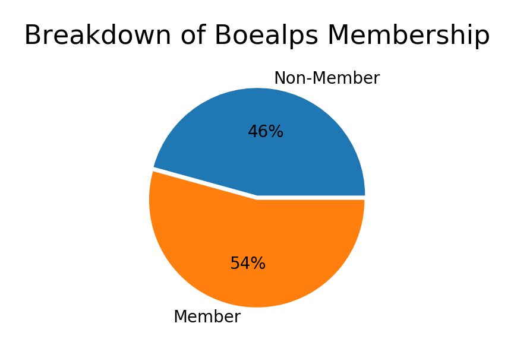

```python
apps.member = apps.member.astype('category')
fig = plt.figure()
ax = apps.groupby('member').size().plot.pie(labels=['Non-Member', 'Member'], figsize=(5, 1.5), fontsize=5,
                                            explode=(.02, .02), autopct='%.0f%%');
plt.title('Breakdown of Boealps Membership', fontsize=8);
ax.set_ylabel('');
fig.dpi = 200
```

```python
display(HTML('<h4>Applicants who are Boealps Members:</h4>'))
for index in apps[apps.member == True].index:
    display(HTML('<li style="line-height:50%">' + index + '</li>'))
```

Applicants who are Boealps Members:

Jane Smith

Bob Smith

Frank Smith

Sue Smith

Sally Smith

Nancy Smith

Steve Smith

Elle Smith

Moe Smith

Mark Smith

David Smith

Chris Smith

Jess Smith

Phil Smith

Karen Smith

Lauren Smith

Jenna Smith

Abby Smith

Mel Smith

### BMC Instructors

Note to self: Ask Sara to send an email to the head instructors asking for feedback.

Print each applicant's lead instructor from when they took the club's intro class so that I can ask for feedback on the applicants.

```python
apps.reset_index().set_index(['bmc_lead', 'name']).sort_values('bmc_lead')['bmc_year']
```

```
bmc_lead                                             name
                                                     John Smith              NaN
                                                     Frank Smith             NaN
                                                     Larry Smith             NaN
                                                     Billy Smith             NaN
                                                     Andrew Smith            NaN
Aaron Barber                                         Lauren Smith           2018
Alex Chiu                                            Mel Smith              2019
                                                     Laura Smith            2019
Chris Vegter                                         Holly Smith            2019
Dan Berdel                                           Bill Smith             2017
                                                     Bob Smith              2018
                                                     Elle Smith             2018
Dan Berdel                                           Jill Smith             2018
Dan Engle                                            David Smith            2017
Dan Martini                                          Jane Smith         19952015
Dan Martini                                          Mary Smith             2015
Dave Wheeler                                         Jeff Smith             2019
                                                     Christine Smith        2019
                                                     Jess Smith             2019
Devin Monas                                          Chris Smith            2016
Jet Lin                                              Abby Smith             2019
                                                     Sally Smith            2019
Morten Hansen                                        Nancy Smith            2016
Ryan Tordowski                                       Molly Smith            2017
Sara Campbell lead with Chris Vegter and Geoff Hill  Phil Smith             2018
Sean O'meara                                         Izzy Smith             2018
Sean OMeara                                          Liz Smith              2017
Sean Omeara                                          Tyler Smith            2018
Steve B                                              Moe Smith              2018
Steve Behrend                                        Jenna Smith            2018
                                                     Karen Smith            2018
                                                     Mark Smith             2018
                                                     Steve Smith            2018
Steve Edgar                                          Sue Smith              2018
Will Herrod                                          Joe Smith              2016
NaN                                                  John Taylor            2015
Name: bmc_year, dtype: Int64
```

Drop the `bmc_lead` column since we're done with it.

```python
apps.drop(['bmc_lead'], axis=1, inplace=True)
```

### Check if any students can't go to Canada

Display names of any students who can't go to Canada. Then drop the `canada` column.

```python
if len(apps[apps.canada == 'No'].index.values) == 0:
    print('All students are good to go for Canada!')
else:
    print("These students can't go to Canada: " + apps[apps.canada == 'No'].index.values)
```

```
All students are good to go for Canada!
```

```python
apps.drop('canada', axis=1, inplace=True)
```

## Ratings

Ratings assigned during student selection:

| Rating | Description |
| --- | --- |
| -1 | Junior instructor |
| 0 | Don't accept |
| 1 | Maybe |
| 2 | Probably |
| 3 | Definitely |

```python
apps['rating'] = np.nan
```

### Styling

To make it easier to see whether an entry is True or False at a glance while looking at a table, replace True entries with an 'X' and False values with a blank string.

```python
def x_true(val):
    if val == True:
        return 'X'
    elif val == False:
        return ''
    else:
        return val
```

```python
apps_summary = apps.drop(['bmc_skills', 'lead_routes', 'climbing_experience', 'reason', 'learning_experience',
                     'goals', 'comments', 'health_concerns', 'missed_outings'], axis=1).applymap(x_true)
apps_summary = apps_summary.sort_values(['member', 'rating', 'bmc'], ascending=False)
```

## Summary of Applications

Create the html table and javascript that will geneate the interactive data table.

```python
table = '<form>\n<table style="width:100%">\n<tr>'
table += '<th>Name</th>\n'

for item in apps_summary.columns:
    table += f'<th>{item}</th>\n'

table += '<tr>\n'

for name, row in apps_summary.iterrows():
    table += '<tr class="main_row">\n'
    table += f'<td>{name}</td>\n'
    for index, val in row.iteritems():
        if index == 'led_outdoors' and val == 'X':
            table += f'<td class="CellWithComment"><b>{val}</b><span class="CellComment">{apps.at[name,"lead_routes"]}</span></td>\n'
        elif index == 'bmc' and val == '':
            table += f'<td class="CellWithComment"><b>[    ]</b><span class="CellComment">{apps.at[name,"bmc_skills"]}</span></td>\n'
        elif index in ['outings', 'lectures'] and val != 'Y':
            table += f'<td class="CellWithComment2"><b>{val}</b><span class="CellComment2">{apps.at[name,"missed_outings"]}</span></td>\n'
        elif index == 'rating':
            table += '<td class="plain"><input type="text"></td>'
        else:
            table += f'<td>{val}</td>\n'
    table += '</tr>\n'
    table += '<tr class="sub_row">\n'
    table += '<td colspan="4"><b>Why do you want to take the BRC? What do you hope to learn?</b><br>'
    table += f'{apps.at[name,"reason"]}</td>\n'
    table += '<td colspan="5"><b>Describe the climbing experience from which you learned the most.</b><br>'
    table += f'{apps.at[name,"learning_experience"]}</td>\n'
    table += '<td colspan="3"><b>What are your climbing goals for this year?</b><br>'
    table += f'{apps.at[name,"goals"]}</td>\n'
    table += '</tr>\n'

    table += '<tr class="sub_row">\n'
    table += '<td colspan="4"><b>Climbing Experience</b><br>'
    table += f'{apps.at[name,"climbing_experience"]}</td>\n'
    table += '<td colspan="5"><b>Comments</b><br>'
    table += f'{apps.at[name,"comments"]}</td>\n'
    table += '<td colspan=3></td>\n'
    table += '</tr>\n'

table += '</table>\n</form>'
```

```python
disp = '''
<html>
<head>
    <style>
        th {
            text-align: center !important;
        }
        tr {
            background-color: white !important;
        }
        tr.main_row {
            background-color: #e6f7ff !important;
            border-style: none none solid none !important;
            border-color: white;
            border-width: 3px
        }

        tr.main_row:hover {
            background-color: PowderBlue !important;
        }

        tr.sub_row {
            display: none;
        }

        tr.sub_row:hover {
            background-color: WhiteSmoke !important;
        }

        tr.main_row td {
            text-align: center !important;
            vertical-align: top !important;
        }

        tr.sub_row td {
            text-align: left !important;
            vertical-align: top !important;
        }

        .CellWithComment{
          position:relative;
        }

        .CellWithComment2{
          position:relative;
        }

        .CellComment{
          display:none;
          position:absolute;
          z-index:100;
          border:1px;
          background-color:white;
          border-style:solid;
          border-width:1px;
          border-color:black;
          padding:3px;
          color:black;
          top:20px;
          left:20px;
          width: 400px;
          text-align: left;
        }

        .CellComment2{
          display:none;
          position:absolute;
          z-index:100;
          border:1px;
          background-color:white;
          border-style:solid;
          border-width:1px;
          border-color:black;
          padding:3px;
          color:black;
          top:20px;
          right:20px;
          width: 400px;
          text-align: left;
        }

        .CellWithComment:hover span.CellComment{
          display:block;
        }

        .CellWithComment2:hover span.CellComment2{
          display:block;
        }

        input {
            width: 40px;
        }


    </style>
</head>
<body>'''
disp += table
disp += '''
<script src="https://ajax.googleapis.com/ajax/libs/jquery/3.2.1/jquery.min.js"></script>
<script>
    //collapse and expand sections

        //$('.main_row').click(function(){
        //    $(this).nextUntil('tr.main_row').slideToggle(200);
        //    });

        $('.main_row').click(function(e){
            if (e.target.nodeName != "INPUT") {
                $(this).nextUntil('tr.main_row').slideToggle(200);
                }
            });



    </script>
</script>
</body>
</html>'''
```

Mouse over bold entries for more information. Click on a row to expand it and see the student's essay question responses. Click on it again to collapse the details. Use the text box in each row to assign a rating to applicants as you read through so you remember what you thought of each applicant when we discuss as a group.

```python
display(HTML(disp))
```

| Name | member | bmc | bmc_year | instructed | lead_class | led_outdoors | instruct_bmc | instruct_brc | take_acc | outings | lectures | rating |
| --- | --- | --- | --- | --- | --- | --- | --- | --- | --- | --- | --- | --- |
| Jane Smith | X | X | 19952015.0 | X |  |  | X |  | X | Y | Y |  |
| **Why do you want to take the BRC? What do you hope to learn?** I want to expand my skill set. I want to be a better BMC instructor. I want more Freedom of the Hills. |  |  |  | **Describe the climbing experience from which you learned the most.** Outside of my 2015, 2017, and 2019 BCC classes, I learned most the the Mt. Skuksan and Mt. Hood climbs that I organized. I found o… |  |  |  |  | **What are your climbing goals for this year?** I hope to organize three bag-it night climbs and hope to put together an expedition to Aconcagua for the Christmas break. |  |  |  |
| **Climbing Experience** None outside of class and class-related outings |  |  |  | **Comments** |  |  |  |  |  |  |  |  |
| Bob Smith | X | X | 2018.0 | X | X | **X**5.6 to 5.7 routes outdoors off exit 38 from I-90 and in Vantage, WA. 1 pitch sport. 5.7 to 5.9 routes on indoor/outdoor gym walls. 1 pitch sport. | X | X | X | Y | Y |  |
| **Why do you want to take the BRC? What do you hope to learn?** I took BMC last year in 2018 and discovered a newfound skill set thru rock climbing. I have taken the skills from BMC and utilized my ti… |  |  |  | **Describe the climbing experience from which you learned the most.** I learned the most from a multipitch sport climb at Smith Rock State Park in which I felt like I understood the process of things … |  |  |  |  | **What are your climbing goals for this year?** Prusik Peak in the Enchantments More exit 38 in North Bend, WA rock climbing. Index, WA rock climbing on trad routes (following) Mazama, Vantage and Red… |  |  |  |
| **Climbing Experience** Guye Peak in Snoqualmie Pinnacle Peak and Castle in Tatoosh Range The Tooth multipitch in Snoqualmie 5.5-5.6 Voyage of the Cowdogs multipitch at Smith Rock State Park in OR 5.8… |  |  |  | **Comments** I’m stoked and very excited to be a part of another awesome BOEALPS class, meet new people, learn new skills, and solidify old ones. Plus, can’t wait to climb around the beautiful PNW! Th… |  |  |  |  |  |  |  |  |
| Sue Smith | X | X | 2018.0 | X |  | **X**5.8-5.9 Sport Routes (Exit 38, Vantage, Smith) 5.10c Tope rope, Vantage | X | X | X | Y | Y |  |
| **Why do you want to take the BRC? What do you hope to learn?** I want to continue my involvement in the close knit communities within Boealps. I love rock climbing and got a taste last summer of mult… |  |  |  | **Describe the climbing experience from which you learned the most.** Fred Beckey Route, Liberty Bell This Route taught me what to expect from multi-pitch alpine climbing in regard to the approach, be… |  |  |  |  | **What are your climbing goals for this year?** Having fun and getting on cracks! Mount Torment The Chief, Squamish Vesper Peak, Ragged Edge Bivy overnight on the Tooth A lot of climbing outside with … |  |  |  |
| **Climbing Experience** Liberty Bell Becky Route (Followed on multipitch Trad) - July 2018 The great northwestern slab, Index, (followed on multipitch trad) - June 2018 Wherever we may roam, Smith roc… |  |  |  | **Comments** |  |  |  |  |  |  |  |  |
| Sally Smith | X | X | 2019.0 |  |  |  | X |  | X | Y | Y |  |
| **Why do you want to take the BRC? What do you hope to learn?** I want to take BRC because I want to start climbing outside and want to start doing that in a class environment with other people learni… |  |  |  | **Describe the climbing experience from which you learned the most.** Vesper Peak (July 2018): The trip I learned the most on was an overnight outing with Vesper and Sperry peaks as climbing objective… |  |  |  |  | **What are your climbing goals for this year?** My goals are to have fun, be safe, push myself, and climb as much as possible this year. Some trips I have in mind are Colchuck/Dragontail Peak, a handf… |  |  |  |
| **Climbing Experience** Almost entirely indoor top roping experience plus one day of outdoor top roping 2 years ago in an REI class where ropes and anchors were set up for us. |  |  |  | **Comments** It's hard for me to imagine instructing BRC since I don't have the skills to do so yet but once I do, I'd expect that I'd want to teach. I'm already excited to instruct BMC and I haven't … |  |  |  |  |  |  |  |  |
| Nancy Smith | X | X | 2016.0 | X |  |  | X |  | X | Y | Y |  |
| **Why do you want to take the BRC? What do you hope to learn?** I want to add alpine 5th class into my skill set so that any mention of 5th class or a rope in a route description doesn't immediately r… |  |  |  | **Describe the climbing experience from which you learned the most.** I learned a lot on the climb to summit Rainier (July 2017, DC route, 2 days, 3-person party). I had failed on the same route the m… |  |  |  |  | **What are your climbing goals for this year?** Eldorado standard route (1 or 2 day), Snowking 2-day trip, get more comfortable on 3rd class terrain, try alpine rock climbing to see if I enjoy it, mos… |  |  |  |
| **Climbing Experience** Very little outdoors- BCC (Leavenworth outing). Indoor climbing: comfortable/efficient 5.8, can do 5.9 but not efficient. Working on 5.10a's currently. No trad or sport routes. |  |  |  | **Comments** Looking forward to it! |  |  |  |  |  |  |  |  |
| Steve Smith | X | X | 2018.0 | X |  | **X**5.8-5.9 Sport Routes (Exit 38) | X | X | X | Y | Y |  |
| **Why do you want to take the BRC? What do you hope to learn?** I want to be prepared to safely and effectively take the ACC. Alpine multi-pitch is my ultimate goal. This summer I hope to learn how to… |  |  |  | **Describe the climbing experience from which you learned the most.** Rainier. Warm conditions combined with many people of many different skill levels showed me the difference between good and bad cl… |  |  |  |  | **What are your climbing goals for this year?** Prusik Peak, Mount Torment, Vesper Peak. I’d like to work on my endurance and efficiency. I’d like to be able to get past an overhang. Climbing all of T… |  |  |  |
| **Climbing Experience** 5.8-5.9 Sport Routes (Exit 38) 5.8-5.10 Sport Routes (Icicle Creek) |  |  |  | **Comments** |  |  |  |  |  |  |  |  |
| Elle Smith | X | X | 2018.0 |  | X | **X**I have led 5.9 and 5.10 sport climbs around North Bend exit 34 & 38, Mazama and at vertical world | X | X | X | Y | Y |  |
| **Why do you want to take the BRC? What do you hope to learn?** I am excited to be more efficient with my current skills and to learn new ones. I'd like to get more training and practice in setting an… |  |  |  | **Describe the climbing experience from which you learned the most.** I climbed Liberty Bell with a party of 6 last September. It was a good lesson in trip planning. We meant to climb two peaks in one… |  |  |  |  | **What are your climbing goals for this year?** My goal is to get more comfortable on the rock, and get more confidence while rock climbing outdoors. I would like to have fun, push myself to climb har… |  |  |  |
| **Climbing Experience** For Mountaineering outside of BCC, I have summited Mt. Rainier and Silver Star in the North Cascades. I have followed on trad routes: The east face of the tooth and the Becky r… |  |  |  | **Comments** |  |  |  |  |  |  |  |  |
| Moe Smith | X | X | 2018.0 | X | X | **X**I've taken a lead class from Vertical world in Seattle. I've lead several routes outdoors at exit 32 and 38. I'm comfortable with 5.7-5.8 lead routes. | X | X | X | Y | Y |  |
| **Why do you want to take the BRC? What do you hope to learn?** I really enjoy climbing and I hope to continue to gain more experience by taking BRC. Most of what I've learned so far has been from cli… |  |  |  | **Describe the climbing experience from which you learned the most.** My first multipitch route was R&D in leavenworth a couple years ago. I followed and this was the first time I had to clean pro as … |  |  |  |  | **What are your climbing goals for this year?** Overall I'm in this to have fun and improve. Last year I took my first trip to Squamish, I'd like to go more and BRC has 2 trips planned so that's great… |  |  |  |
| **Climbing Experience** I've been rock climbing for 2.5 years now. I mostly climb top rope with the occasional sport route. I'm confidant climbing up to 5.9 with the occasional 5.10. Gym climbing is m… |  |  |  | **Comments** |  |  |  |  |  |  |  |  |
| Mark Smith | X | X | 2018.0 | X | X |  | X | X | X | Y | Y |  |
| **Why do you want to take the BRC? What do you hope to learn?** I want to learn the technical skills necessary for multipitch (at least following but also get exposure to what leaders are doing), get … |  |  |  | **Describe the climbing experience from which you learned the most.** Taking this question literally I'd probably answer St. Ed's when I was a BCC student, but you already know what I learned there so… |  |  |  |  | **What are your climbing goals for this year?** I want to climb multipitch routes at places like Index and Squamish, also alpine climbs in the Cascades. Some specific climbs on my list include Vesper,… |  |  |  |
| **Climbing Experience** I've been gym climbing pretty regularly since 2015. Lead class was for indoor climbing at Vertical World and I practice lead climbing there about once a week. I've climbed in s… |  |  |  | **Comments** |  |  |  |  |  |  |  |  |
| David Smith | X | X | 2017.0 | X |  |  | X | X |  | Y | Y |  |
| **Why do you want to take the BRC? What do you hope to learn?** To explore physical and mental challenges in environment where the scenery is beautiful and the climbing partner trustworthy. And to exp… |  |  |  | **Describe the climbing experience from which you learned the most.** In addition to all outings during the 2017 Basic Alpine Class with the leader Dan Engle, my memorable trip is attempting Mt. Raine… |  |  |  |  | **What are your climbing goals for this year?** Combination of sport and trad: Mazama area: Routes in Crackstar Lounge, Routes in Spearhead Base, Routes in Déjà vu, Mt. Triumph, etc. Squamish, British… |  |  |  |
| **Climbing Experience** Indoors: Vertical World, Stone Garden, Summit Everett Outdoors- Sport: a few times at Exit 38, mainly 5.7 and 5.8 Sport |  |  |  | **Comments** Rosie Melookaran has kindly permitted me to use her as reference. I think Alex Chiu and Mick Ostroff would not mind. Whould they? |  |  |  |  |  |  |  |  |

[output cut: 78 more lines]